# Untitled

### Install Packages

The packages required are `tidyverse` (included relevant packages for data analyses such as ggplot2, readr and dplyr),`ggiraph`,`plotly`,`DT`,`patchwork`,`gganimate`,`readxl`,`gifski`,`gapminder`,`knitr`,`flexdashboard`,`kableExtra`

The code chunk below is used to install and load the required packages onto RStudio.

```r
packages = c('ggiraph','plotly','DT','patchwork','gganimate','tidyverse','readxl','gifski','gapminder','knitr','flexdashboard')
for (p in packages){
  if(!require(p, character.only =T)){
    install.packages(p)
    }
library(p,character.only =T)
}
```

# **Take-home exercise 2**

Design an age-sex pyramid based data visualization to show the changes of demographic structure of Singapore by age cohort and gender between 2000-2020 at planning area level.  
###Import data:

```r
pop2010 <- read.csv("data/respopagesextod2000to2010.csv",head = T)
pop2020 <- read.csv("data/respopagesextod2011to2020.csv",head = T)
head(pop2010)
```

```
          PA        SZ     AG   Sex
1 Ang Mo Kio Cheng San 0_to_4 Males
2 Ang Mo Kio Cheng San 0_to_4 Males
3 Ang Mo Kio Cheng San 0_to_4 Males
4 Ang Mo Kio Cheng San 0_to_4 Males
5 Ang Mo Kio Cheng San 0_to_4 Males
6 Ang Mo Kio Cheng San 0_to_4 Males
                                      TOD Pop Time
1                 HDB 1- and 2-Room Flats  20 2000
2                        HDB 3-Room Flats 480 2000
3                        HDB 4-Room Flats 220 2000
4          HDB 5-Room and Executive Flats  80 2000
5 HUDC Flats (excluding those privatised)   0 2000
6                       Landed Properties   0 2000
```

```r
head(pop2020)
```

```
          PA                     SZ     AG   Sex
1 Ang Mo Kio Ang Mo Kio Town Centre 0_to_4 Males
2 Ang Mo Kio Ang Mo Kio Town Centre 0_to_4 Males
3 Ang Mo Kio Ang Mo Kio Town Centre 0_to_4 Males
4 Ang Mo Kio Ang Mo Kio Town Centre 0_to_4 Males
5 Ang Mo Kio Ang Mo Kio Town Centre 0_to_4 Males
6 Ang Mo Kio Ang Mo Kio Town Centre 0_to_4 Males
                                      TOD Pop Time
1                 HDB 1- and 2-Room Flats   0 2011
2                        HDB 3-Room Flats  10 2011
3                        HDB 4-Room Flats  30 2011
4          HDB 5-Room and Executive Flats  50 2011
5 HUDC Flats (excluding those privatised)   0 2011
6                       Landed Properties   0 2011
```

Join two sheets together using `rbind()` in Base R:

```r
pop_data <- rbind(pop2010, pop2020)
```

## A age-sex pyramid showing the demographic structure of Singapore by age cohort and gender at the planning area level.

### Data Wrangling

Select the columns that would be useful for data wrangling, since we only consider the population by gender and age.  
Aggregate the population measure using `group_by` and `summaries` functions from the `dplyr` package to sum up population by *Sex*, *AG* and *PA*.

```r
age_sex <- pop_data %>%
  select(c("Sex", "AG","Pop","PA","Time")) %>%
  group_by(`Sex`,`AG`,`PA`,`Time`) %>%
  summarise(Population=sum(Pop))%>%
  ungroup()
head(age_sex)
```

```
# A tibble: 6 x 5
  Sex     AG     PA          Time Population
  <chr>   <chr>  <chr>      <int>      <int>
1 Females 0_to_4 Ang Mo Kio  2000       4460
2 Females 0_to_4 Ang Mo Kio  2001       4320
3 Females 0_to_4 Ang Mo Kio  2002       4220
4 Females 0_to_4 Ang Mo Kio  2003       4010
5 Females 0_to_4 Ang Mo Kio  2004       3870
6 Females 0_to_4 Ang Mo Kio  2005       3640
```

Upon observation we found out that the age group 5_to_9 appeared in the middle of the axis. For the next step, we prepare the dataframe by arranging the Age into different Age groups.

```r
age_sex <- age_sex %>%
  select(c("Sex", "AG","Population","PA","Time")) %>%
  arrange(.,AG) %>%
  mutate(AG = dplyr::case_when(
    AG>= 00 & AG <10 ~ "00-09",
    AG>= 10 & AG <20 ~ "10-19",
    AG>= 20 & AG <30 ~ "20-29",
    AG>= 30 & AG <40 ~ "30-39",
    AG>= 40 & AG <50 ~ "40-49",
    AG>= 50 & AG <59 ~ "50-59",
    AG>= 60 & AG <69 ~ "60-69",
    AG>= 70 & AG <79 ~ "70-79",
    AG>= 80 & AG <89 ~ "80-89",
    AG>= 90 ~ "90_and_over"))

head(age_sex)
```

```
# A tibble: 6 x 5
  Sex     AG    Population PA          Time
  <chr>   <chr>      <int> <chr>      <int>
1 Females 00-09       4460 Ang Mo Kio  2000
2 Females 00-09       4320 Ang Mo Kio  2001
3 Females 00-09       4220 Ang Mo Kio  2002
4 Females 00-09       4010 Ang Mo Kio  2003
5 Females 00-09       3870 Ang Mo Kio  2004
6 Females 00-09       3640 Ang Mo Kio  2005
```

Set the bar plots for male populations to the **left side** (thus *negative sign* `-`)

```r
age_sex$Population <- ifelse(age_sex$Sex == "Males", -1*age_sex$Population, age_sex$Population)
```

For further comparison on the PA level, we set the PA filter for **Ang Mo Kio** and **Bedok**. And create two dataframes, AS_AMK and AS_Bd

```r
AS_AMK<-age_sex %>%
  filter(., PA == 'Ang Mo Kio')

AS_Bd<-age_sex %>%
  filter(.,PA == 'Bedok')

#check header
kable(head(AS_AMK))
```

| Sex | AG | Population | PA | Time |
| --- | --- | --- | --- | --- |
| Females | 00-09 | 4460 | Ang Mo Kio | 2000 |
| Females | 00-09 | 4320 | Ang Mo Kio | 2001 |
| Females | 00-09 | 4220 | Ang Mo Kio | 2002 |
| Females | 00-09 | 4010 | Ang Mo Kio | 2003 |
| Females | 00-09 | 3870 | Ang Mo Kio | 2004 |
| Females | 00-09 | 3640 | Ang Mo Kio | 2005 |

```r
kable(head(AS_Bd))
```

| Sex | AG | Population | PA | Time |
| --- | --- | --- | --- | --- |
| Females | 00-09 | 7800 | Bedok | 2000 |
| Females | 00-09 | 7650 | Bedok | 2001 |
| Females | 00-09 | 7410 | Bedok | 2002 |
| Females | 00-09 | 7040 | Bedok | 2003 |
| Females | 00-09 | 6860 | Bedok | 2004 |
| Females | 00-09 | 6590 | Bedok | 2005 |

### The Static Plot

Animation consist of individual pages. Establish what the plot will display by mapping variables to aesthetics. A population pyramid is a special kind of bar graph. It displays male and female populations on back-to-back x axes.  
Male population values were made negative. This allows a “mirror image” of the two graphs displayed along the shared x axis.

```r
female_AMK <- AS_AMK %>%
  filter(.,Sex == 'Females')
male_AMK <- AS_AMK %>%
  filter(.,Sex == 'Males')

female_Bd <-AS_Bd %>%
  filter(.,Sex == "Females")
male_Bd <-AS_Bd %>%
  filter(.,Sex == "Males")
```

###Plotting

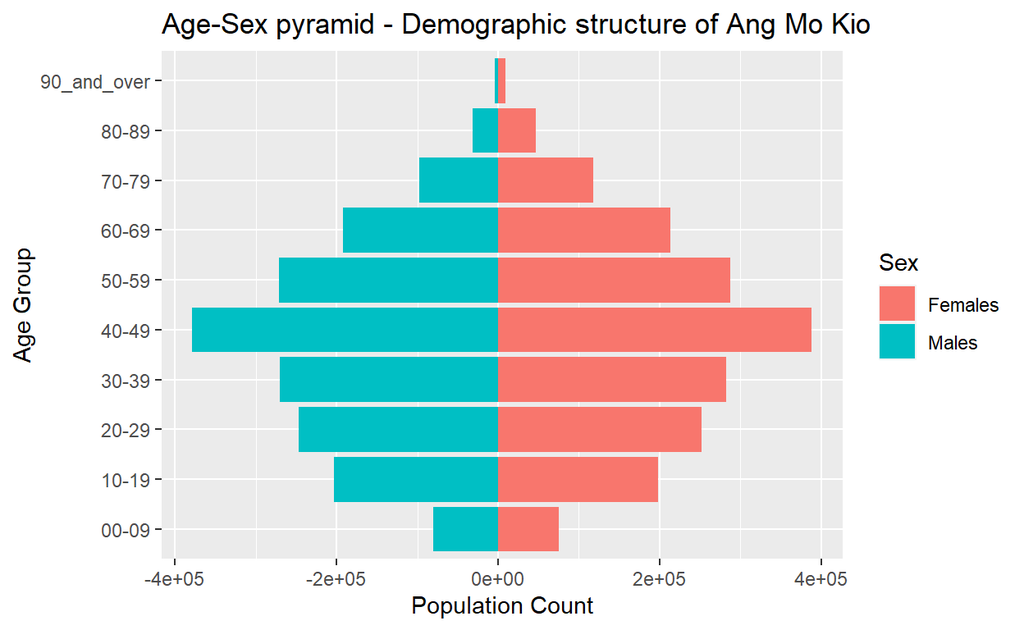

```r
AS_AMK_p<- ggplot(AS_AMK, aes(x = AG, y = Population, fill = Sex)) +
  geom_bar(data = female_AMK, stat = "identity") +
  geom_bar(data = male_AMK,stat = "identity") +
  xlab('Age Group') +
  ylab('Population Count') +
  ggtitle('Age-Sex pyramid - Demographic structure of Ang Mo Kio')+
  coord_flip()

AS_AMK_p
```

#### Formatting the x-axis

```r
xbrks <- seq(-500000, 500000, 100000)
xlabls <- paste0(as.character(c(seq(500, 0, -100), seq(100, 500, 100))), "k")
# creating new intervals and labels for x-axis
```

Finalize the data for Ang Mo Kio

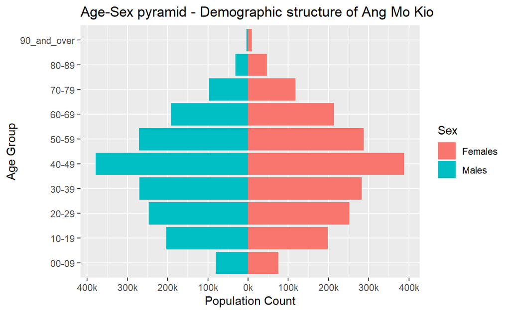

```r
AS_AMK_p<- ggplot(AS_AMK, aes(x = AG, y = Population, fill = Sex)) +
  geom_bar(data=female_AMK,stat = "identity") +
  geom_bar(data=male_AMK,stat = "identity") +
  scale_y_continuous(breaks = xbrks, labels=xlabls)+
  xlab('Age Group') +
  ylab('Population Count') +
  ggtitle('Age-Sex pyramid - Demographic structure of Ang Mo Kio')+
  coord_flip()

AS_AMK_p
```

Apply the similar code chunk for Bedok

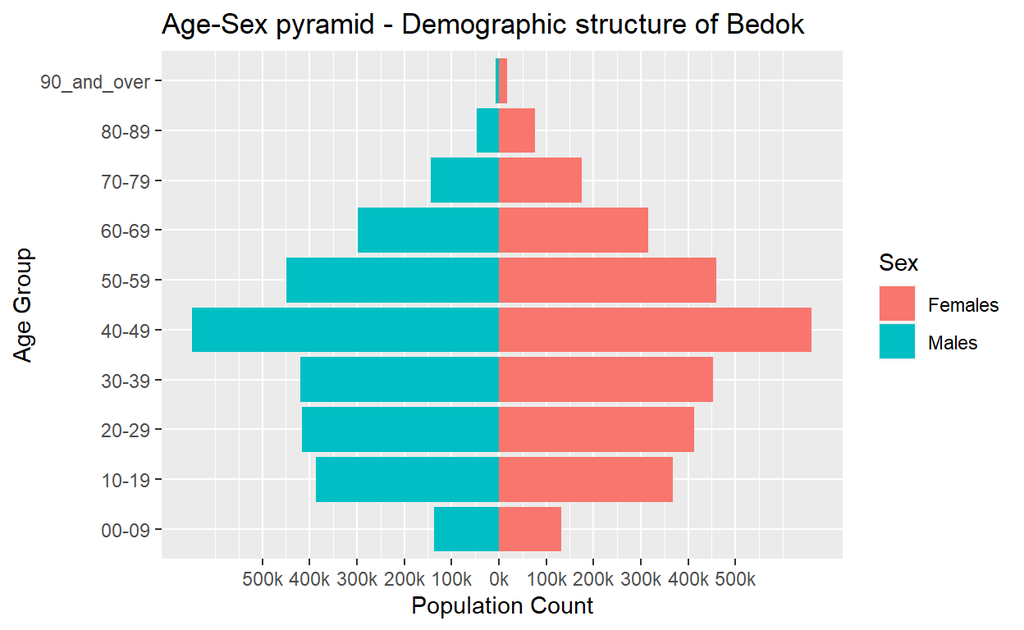

```r
AS_Bd_p<- ggplot(AS_Bd, aes(x = AG, y = Population, fill = Sex)) +
  geom_bar(data=female_Bd,stat = "identity") +
  geom_bar(data=male_Bd,stat = "identity") +
  scale_y_continuous(breaks = xbrks, labels=xlabls)+
  xlab('Age Group') +
  ylab('Population Count') +
  ggtitle('Age-Sex pyramid - Demographic structure of Bedok')+
  coord_flip()

AS_Bd_p
```

```r
library(ggplot2)
library(gganimate)
AS_AMK_ani<-ggplot(AS_AMK, aes(x = AG, y = Population, fill = Sex)) +
  geom_bar(data=female_AMK,stat = "identity") +
  geom_bar(data=male_AMK,stat = "identity") +
  xlab('Age Group') +
  ylab('Population Count') +
  # Here comes the gganimate code
  transition_states(Time,transition_length = 3, state_length = 1, wrap=TRUE) +
  enter_fade() +
  exit_fade()+
  labs(title = 'Year: {frame_time}',
       x = '% AG',
       y = '% Population') +
  transition_time(Year) +
  ease_aes('cute-in-out')
```

Then plot for Bedok area:

```r
AS_Bd_ani<-ggplot(AS_Bd, aes(x = AG, y = Population, fill = Sex)) +
  geom_bar(data=female_Bd,stat = "identity") +
  geom_bar(data=male_Bd,stat = "identity") +
  xlab('Age Group') +
  ylab('Population Count') +
  # Here comes the gganimate code
  transition_states(Time,transition_length = 3, state_length = 1, wrap=TRUE) +
  enter_fade() +
  exit_fade()+
  labs(title = 'Year: {frame_time}',
       x = '% AG',
       y = '% Population') +
  transition_time(Year) +
  ease_aes('cubic-in-out')
```